# Long Island Rail Road (LIRR) Train Operation Analysis

## Part #1

- Group Project
- Instructor: Sean Barns
- Students:
  - Xukun LIU: [Linkedin](https://www.linkedin.com/in/xukunliu1994/) / [www.xukun-liu.com](https://www.xukun-liu.com/)
  - Jing LIU: [Linkedin](https://www.linkedin.com/in/jing-liu-202639171/)
  - Jing WANG: [Linkedin](https://www.linkedin.com/in/jing-wang-943b03171/)

# Project Progress Report:

## 1. Introduction:

### 1.1. The dataset:

The data set we are going to use is from the Metropolitan Transportation Authority (MTA) official website: http://wx3z.lirr.org “Long Island Rail Road (LIRR) Delayed and Canceled Train Information” recorded all the train operation information. (e.g. the scheduled delayed, canceled or partially canceled, or arrived 6 or more min behind the scheduled arrival)

### 1.2. Project Goal

Our goal is, by analyzing this dataset, to find some pattern of the train delay situations: We are trying to give suggestions on the accuracy of the arrival-prediction system to the Metropolitan Transportation Authority and also provide a predictive mechanism to the commuters. By analyzing the collected data from the Metropolitan Transportation Authority (MTA) official website, we wish to find some pattern on delayed and canceled trains.

## 2. Data Preparation:

### 2.1. Data Description:

The original version of the data is monthly tabular reports (including date, branch, scheduled departure & arrival, etc). The main columns in the website html are:

- Date: The date of the train.
- Branch: The track the train will be running.
- Depart: The station the train will depart from.
- Arrive: The station the train will arrive at.
- Depart_Time: The time at which the train will depart.
- Arrive_Time: The time at which the train will arrive.
- Period: The period of the whole day the train will run.
- Train_ID: The unique identification number of the train.
- Status: the status of the train (Cancelled, Late - #mins)

### 2.2. Data Collection

We are going to write a python script to scrape data from their website. Since their website only allows us to pull data within a 31 days range, if we want to analyze on a larger scale dataset, we also need to loop through the historical data from their website.  
we collected the data, ranging from 2011 to 2018, on the official website. In this part, Since the data are stored on the webpage in HTML table format, we may need to use some packages such as Request or BeautifulSoup. We have to notice that:

- date={startMonth}%2F{startDate}%2F{startDate}&to_date={endMonth}%2F{endDate}%2F{endYear}
- It is critically important that the webpage path following a certain pattern
- The webpage path could tell us the data starting and ending date
- We could use this feature to visit a web and tell exactly date range we want
- For each webpage, it won’t allow showing data more than 31 days range.
- Information available from 07/01/2010 to 03/28/2019.

### 2.3. Data Cleaning

After we collected the data, we found the data stored in the data set in a string format. For instance, in column Status: ‘Late - 10 mins’  
To get valuable information and useful data, we may need to do data transformation, text processing to transfer the string into a date, time, status, related minutes… etc.

- Late_Mins: The minutes of the train behind schedule.
- Status_type: Whether the status of the train was Late, Canceled, Partially Canceled.
- weekend: Whether it is the weekend.

## 3. Data Analysis Direction

### 3.1. Objective:

In this step, we will import the cleaned and aggregated data into analysis tools. These tools allow us to explore the data, find inner patterns in it, and ask and answer what-if questions. This is the process by which sense is made of data gathered in research by proper application of statistical methods.

### 3.2. Define problems to be solved:

In this step, we would come up with some questions and by answering them through visualization, we will acquire meaningful insights out of huge data set. The problems are as follows:

- What was the longest delayed time?
- Which line delays the most?
- What is the average delay time?
- Which day or days of the week, the train perform the worst?
- How many Canceled, Late, and Partially Canceled entries are in each year？
- Is the delay associated with a certain station？
- Average late minutes by station and month in Year2018？

### 3.3. Insight from visualization:

In this step, we would find out what factors might lead to different status types of trains.

## 4. Project Progress

due to the revision of our project:

- 03/26: submit a new project proposal
- 03/27-03/28: pulled the dataset of year 2018 and attempted on data transformation.
- 03/29-03/30: collected the data from 2011 to 2018, using packages such as Request or Beautiful Soup.
- 03/31: data cleaning and data transformation.
- 04/01 - 04/02: visualized on existing columns to prove our assumptions of potential patterns.
- 04/02 - : revise previous work and realize the remaining objectives.

## 5. Future Work

To answer some of the previous questions, we may need to collect some data from other sources. For instance: the official schedule of the trains or the historical weather information.

### 5.2.

Other factors might affect whether the train is late or canceled,such as weather. In this way, we can crawl data about the weather on the official website and relate it to the entries in the current dataset and test whether trains' status types are related to weather.

### 5.3.

We can choose and train appropriate models to predict the total number of delayed trains under different weather conditions. And selection of the model will rely on the accuracy of prediction on the data of two randomly selected years.

[figure not shown]

## Data Preparation

### Take a look at the Web Structure

```python
from bs4 import BeautifulSoup
import requests
```

```python
path = 'http://wx3z.lirr.org/latetrains/?date=03%2F02%2F2019&to_date=03%2F03%2F2019'
```

```python
myhtml = requests.get(path)
mySoup = BeautifulSoup(myhtml.text,'html5lib')
```

```python
mySoup.find_all('tr')[0]
```

```
<tr>
					<th>Date</th>
					<th>Branch</th>
					<th colspan="3">Scheduled Departure &amp; Arrival</th>
					<th>Period</th>
					<th>Train #</th>
					<th>Status</th>
				</tr>
```

**The html table contain the following info:**

- Date
- Branch
- Scheduled Departure
- Arrival
- Period
- Train #
- Status

**In each column, all the value has the same data format**

```python
mySoup.find_all('tr')[1]
```

```
<tr>
					<td>03/02/2019</td>
					<td>Babylon</td>
					<td class="bold" width="50">Depart:<br/>Arrive:</td>
					<td width="175">Penn Station<br/>Babylon Station</td>
					<td align="right" width="50">12:43AM<br/> 2:01AM</td>
					<td align="center">Off Peak</td>
					<td align="center">6002</td>
					<td align="center">Late - 8 mins</td>
				</tr>
```

- Define a function: html_dict_list
- The function reads in the html path
- Use package download the source code
- Convert the html table into dictionry and then append to a list

```python
def html_dict_list(html_path):
    # Reuqire package: BeautifulSoup from bs4
    # Reuqire package: requests
    myhtml = requests.get(html_path)
    mySoup = BeautifulSoup(myhtml.text,'html5lib')
    data_list = []
    for idx, tr in enumerate(mySoup.find_all('tr')):
        if idx != 0:
            tds = tr.find_all('td')
            temp_dict = {
                'Date':tds[0].contents[0],
                'Branch':tds[1].contents[0],
                'Depart':tds[3].contents[0],
                'Arrive':tds[3].contents[2],
                'Depart_Time':tds[4].contents[0],
                'Arrive_Time':tds[4].contents[2],
                'Period':tds[5].contents[0],
                'Train_ID':tds[6].contents[0],
                'Status':tds[7].contents[0],
            }
            data_list.append(temp_dict)
    return data_list
```

```python
import pandas as pd
import datetime
```

- http://wx3z.lirr.org/latetrains/?date=03%2F01%2F2019&to_date=03%2F02%2F2019
- http://wx3z.lirr.org/latetrains/?date=03%2F01%2F2019&to_date=03%2F03%2F2019
- http://wx3z.lirr.org/latetrains/?date=03%2F02%2F2019&to_date=03%2F03%2F2019
- date=**{startMonth}**%2F**{startDate}**%2F**{startDate}**&to_date=**{endMonth}**%2F**{endDate}**%2F**{endYear}**
  - It is critical important that the website path following a certain patt, which tell us the data start and ending date
  - We could use this feature to visit a web and tell exactly date range we want
  - Warning: Max information (date) available from 07/01/2010 to 03/25/2019.

```python
# define the data start and ending date
# we are going to collect the data from 2011 to 2018
# 8 years in total
startYear = 2011
startMonth = 1
startDate = 1

endYear = 2018
endMonth = 12
endDate = 31
```

```python
startDay = datetime.date(year = startYear, month = startMonth, day = startDate)
```

```python
endDay = datetime.date(year = endYear, month = endMonth, day = endDate)
```

```python
startDay <= endDay
```

```
True
```

- Warning: Date range may not exceed 31 days.
- This is limitation set by the website
- Once the data collecting period exceeds 31 days, out path will be illegal
- So to make sure our path working and easy to read, we set our increment parameter to 30

```python
dateDelta = datetime.timedelta(days = 30)
```

- leftDay: the date start to read data
- rightDay: the date stop to read data

```python
leftDay = startDay
rightDay = leftDay + dateDelta

dt = []

while(leftDay < endDay):

    real_rightDay = min(rightDay,endDay)

    sMonth = str(leftDay.month).zfill(2)
    sDate = str(leftDay.day).zfill(2)
    sYear = str(leftDay.year).zfill(4)
    eMonth = str(real_rightDay.month).zfill(2)
    eDate = str(real_rightDay.day).zfill(2)
    eYear = str(real_rightDay.year).zfill(4)

    path_fixed = 'http://wx3z.lirr.org/latetrains/?date='
    # '{sMonth}%2F{sDate}%2F{sYear}&to_date={eMonth}%2F{eDate}%2F{eYear}'
    path_var = '{}%2F{}%2F{}&to_date={}%2F{}%2F{}'.format(sMonth,sDate,sYear,eMonth,eDate,eYear)

    temp_path = path_fixed + path_var
    print(temp_path)

    dt = dt + html_dict_list(temp_path)

    leftDay = rightDay + datetime.timedelta(days=1)
    rightDay = leftDay + dateDelta
```

```
http://wx3z.lirr.org/latetrains/?date=01%2F01%2F2011&to_date=01%2F31%2F2011
http://wx3z.lirr.org/latetrains/?date=02%2F01%2F2011&to_date=03%2F03%2F2011
http://wx3z.lirr.org/latetrains/?date=03%2F04%2F2011&to_date=04%2F03%2F2011
http://wx3z.lirr.org/latetrains/?date=04%2F04%2F2011&to_date=05%2F04%2F2011
http://wx3z.lirr.org/latetrains/?date=05%2F05%2F2011&to_date=06%2F04%2F2011
http://wx3z.lirr.org/latetrains/?date=06%2F05%2F2011&to_date=07%2F05%2F2011
http://wx3z.lirr.org/latetrains/?date=07%2F06%2F2011&to_date=08%2F05%2F2011
http://wx3z.lirr.org/latetrains/?date=08%2F06%2F2011&to_date=09%2F05%2F2011
http://wx3z.lirr.org/latetrains/?date=09%2F06%2F2011&to_date=10%2F06%2F2011
http://wx3z.lirr.org/latetrains/?date=10%2F07%2F2011&to_date=11%2F06%2F2011
http://wx3z.lirr.org/latetrains/?date=11%2F07%2F2011&to_date=12%2F07%2F2011
http://wx3z.lirr.org/latetrains/?date=12%2F08%2F2011&to_date=01%2F07%2F2012
http://wx3z.lirr.org/latetrains/?date=01%2F08%2F2012&to_date=02%2F07%2F2012
http://wx3z.lirr.org/latetrains/?date=02%2F08%2F2012&to_date=03%2F09%2F2012
http://wx3z.lirr.org/latetrains/?date=03%2F10%2F2012&to_date=04%2F09%2F2012
http://wx3z.lirr.org/latetrains/?date=04%2F10%2F2012&to_date=05%2F10%2F2012
http://wx3z.lirr.org/latetrains/?date=05%2F11%2F2012&to_date=06%2F10%2F2012
http://wx3z.lirr.org/latetrains/?date=06%2F11%2F2012&to_date=07%2F11%2F2012
http://wx3z.lirr.org/latetrains/?date=07%2F12%2F2012&to_date=08%2F11%2F2012
http://wx3z.lirr.org/latetrains/?date=08%2F12%2F2012&to_date=09%2F11%2F2012
http://wx3z.lirr.org/latetrains/?date=09%2F12%2F2012&to_date=10%2F12%2F2012
http://wx3z.lirr.org/latetrains/?date=10%2F13%2F2012&to_date=11%2F12%2F2012
http://wx3z.lirr.org/latetrains/?date=11%2F13%2F2012&to_date=12%2F13%2F2012
http://wx3z.lirr.org/latetrains/?date=12%2F14%2F2012&to_date=01%2F13%2F2013
http://wx3z.lirr.org/latetrains/?date=01%2F14%2F2013&to_date=02%2F13%2F2013
http://wx3z.lirr.org/latetrains/?date=02%2F14%2F2013&to_date=03%2F16%2F2013
http://wx3z.lirr.org/latetrains/?date=03%2F17%2F2013&to_date=04%2F16%2F2013
http://wx3z.lirr.org/latetrains/?date=04%2F17%2F2013&to_date=05%2F17%2F2013
http://wx3z.lirr.org/latetrains/?date=05%2F18%2F2013&to_date=06%2F17%2F2013
http://wx3z.lirr.org/latetrains/?date=06%2F18%2F2013&to_date=07%2F18%2F2013
http://wx3z.lirr.org/latetrains/?date=07%2F19%2F2013&to_date=08%2F18%2F2013
http://wx3z.lirr.org/latetrains/?date=08%2F19%2F2013&to_date=09%2F18%2F2013
http://wx3z.lirr.org/latetrains/?date=09%2F19%2F2013&to_date=10%2F19%2F2013
http://wx3z.lirr.org/latetrains/?date=10%2F20%2F2013&to_date=11%2F19%2F2013
http://wx3z.lirr.org/latetrains/?date=11%2F20%2F2013&to_date=12%2F20%2F2013
http://wx3z.lirr.org/latetrains/?date=12%2F21%2F2013&to_date=01%2F20%2F2014
http://wx3z.lirr.org/latetrains/?date=01%2F21%2F2014&to_date=02%2F20%2F2014
http://wx3z.lirr.org/latetrains/?date=02%2F21%2F2014&to_date=03%2F23%2F2014
http://wx3z.lirr.org/latetrains/?date=03%2F24%2F2014&to_date=04%2F23%2F2014
http://wx3z.lirr.org/latetrains/?date=04%2F24%2F2014&to_date=05%2F24%2F2014
```

[output cut: 40 more lines]

```
http://wx3z.lirr.org/latetrains/?date=10%2F16%2F2017&to_date=11%2F15%2F2017
http://wx3z.lirr.org/latetrains/?date=11%2F16%2F2017&to_date=12%2F16%2F2017
http://wx3z.lirr.org/latetrains/?date=12%2F17%2F2017&to_date=01%2F16%2F2018
http://wx3z.lirr.org/latetrains/?date=01%2F17%2F2018&to_date=02%2F16%2F2018
http://wx3z.lirr.org/latetrains/?date=02%2F17%2F2018&to_date=03%2F19%2F2018
http://wx3z.lirr.org/latetrains/?date=03%2F20%2F2018&to_date=04%2F19%2F2018
http://wx3z.lirr.org/latetrains/?date=04%2F20%2F2018&to_date=05%2F20%2F2018
http://wx3z.lirr.org/latetrains/?date=05%2F21%2F2018&to_date=06%2F20%2F2018
http://wx3z.lirr.org/latetrains/?date=06%2F21%2F2018&to_date=07%2F21%2F2018
http://wx3z.lirr.org/latetrains/?date=07%2F22%2F2018&to_date=08%2F21%2F2018
http://wx3z.lirr.org/latetrains/?date=08%2F22%2F2018&to_date=09%2F21%2F2018
http://wx3z.lirr.org/latetrains/?date=09%2F22%2F2018&to_date=10%2F22%2F2018
http://wx3z.lirr.org/latetrains/?date=10%2F23%2F2018&to_date=11%2F22%2F2018
http://wx3z.lirr.org/latetrains/?date=11%2F23%2F2018&to_date=12%2F23%2F2018
http://wx3z.lirr.org/latetrains/?date=12%2F24%2F2018&to_date=12%2F31%2F2018
```

### Data Cleaning

- Convert the data type (dict -> dataframe) for future analysis

```python
dt = pd.DataFrame(dt)
```

```python
dt.keys()
```

```
Index(['Arrive', 'Arrive_Time', 'Branch', 'Date', 'Depart', 'Depart_Time',
       'Period', 'Status', 'Train_ID'],
      dtype='object')
```

```python
dt = dt[['Date','Branch','Depart','Arrive','Depart_Time','Arrive_Time','Period','Train_ID','Status']]
```

```python
dt.head()
```

|  | Date | Branch | Depart | Arrive | Depart_Time | Arrive_Time | Period | Train_ID | Status |
| --- | --- | --- | --- | --- | --- | --- | --- | --- | --- |
| 0 | 01/01/2011 | Hunt. Hicks. | Huntington Station | Penn Station | 12:35AM | 1:42AM | Off Peak | 7603 | Late - 37 mins |
| 1 | 01/01/2011 | Ronk. (greenpt.) | Ronkonkoma Station | Penn Station | 12:44AM | 2:02AM | Off Peak | 8001 | Late - 14 mins |
| 2 | 01/01/2011 | Ronk. (greenpt.) | Penn Station | Ronkonkoma Station | 12:46AM | 2:05AM | Off Peak | 8102 | Late - 17 mins |
| 3 | 01/01/2011 | Port Jefferson | Huntington Station | Port Jefferson Station | 12:54AM | 1:41AM | Off Peak | 6600 | Late - 19 mins |
| 4 | 01/01/2011 | Montauk | Jamaica Station | Montauk Station | 1:10AM | 3:57AM | Off Peak | 8700 | Late - 12 mins |

```python
#dt['Status']
```

```python
import re
```

```python
def re_min_search(pat,S):
    m = re.search(pat, S)
    if m != None:
        return int(m.group(0))
    else:
        return None
```

```python
dt['Late_Mins'] = dt['Status'].apply(lambda x: re_min_search('\d+',x))
```

```python
def re_status_search(pat,S):
    m = re.search(pat, S)
    if m != None:
        return 'Late'
    else:
        return S
```

```python
dt['Status_type'] = dt['Status'].apply(lambda x: re_status_search('\d+',x))
```

```python
len(dt['Late_Mins'])
```

```
135109
```

```python
dt['Late_Mins'].isnull().sum()
```

```
12691
```

```python
dt['Late_Mins'].notnull().sum()
```

```
122418
```

```python
dt['Year'] = dt['Date'].apply(lambda x: int(x[-4:]))
dt['Month'] = dt['Date'].apply(lambda x: int(x[0:2]))
dt['Day'] = dt['Date'].apply(lambda x: int(x[-7:-5]))
```

```python
def is_weekend(year,month,day):
    that_day = datetime.date(year,month,day)
    if that_day.isoweekday() >= 5:
        return 'yes'
    else:
        return 'no'
```

```python
dt['weekend'] = dt['Date'].apply(lambda x: is_weekend(int(x[-4:]),int(x[0:2]),int(x[-7:-5])))
```

```python
dt.head()
```

|  | Date | Branch | Depart | Arrive | Depart_Time | Arrive_Time | Period | Train_ID | Status | Late_Mins | Status_type | Year | Month | Day | weekend |
| --- | --- | --- | --- | --- | --- | --- | --- | --- | --- | --- | --- | --- | --- | --- | --- |
| 0 | 01/01/2011 | Hunt. Hicks. | Huntington Station | Penn Station | 12:35AM | 1:42AM | Off Peak | 7603 | Late - 37 mins | 37.0 | Late | 2011 | 1 | 1 | yes |
| 1 | 01/01/2011 | Ronk. (greenpt.) | Ronkonkoma Station | Penn Station | 12:44AM | 2:02AM | Off Peak | 8001 | Late - 14 mins | 14.0 | Late | 2011 | 1 | 1 | yes |
| 2 | 01/01/2011 | Ronk. (greenpt.) | Penn Station | Ronkonkoma Station | 12:46AM | 2:05AM | Off Peak | 8102 | Late - 17 mins | 17.0 | Late | 2011 | 1 | 1 | yes |
| 3 | 01/01/2011 | Port Jefferson | Huntington Station | Port Jefferson Station | 12:54AM | 1:41AM | Off Peak | 6600 | Late - 19 mins | 19.0 | Late | 2011 | 1 | 1 | yes |
| 4 | 01/01/2011 | Montauk | Jamaica Station | Montauk Station | 1:10AM | 3:57AM | Off Peak | 8700 | Late - 12 mins | 12.0 | Late | 2011 | 1 | 1 | yes |

- in time colmuns: contain special string: \xa
- to avoid they affcet the future analysis, remove them

```python
dt.iloc[1]['Arrive_Time']
```

```
'\xa02:02AM'
```

```python
dt['Arrive_Time'] = dt['Arrive_Time'].apply(lambda x: re.search('\d*:\d*[AP]M',x).group(0))
dt['Depart_Time'] = dt['Depart_Time'].apply(lambda x: re.search('\d*:\d*[AP]M',x).group(0))
```

```python
dt.head()
```

|  | Date | Branch | Depart | Arrive | Depart_Time | Arrive_Time | Period | Train_ID | Status | Late_Mins | Status_type | Year | Month | Day | weekend |
| --- | --- | --- | --- | --- | --- | --- | --- | --- | --- | --- | --- | --- | --- | --- | --- |
| 0 | 01/01/2011 | Hunt. Hicks. | Huntington Station | Penn Station | 12:35AM | 1:42AM | Off Peak | 7603 | Late - 37 mins | 37.0 | Late | 2011 | 1 | 1 | yes |
| 1 | 01/01/2011 | Ronk. (greenpt.) | Ronkonkoma Station | Penn Station | 12:44AM | 2:02AM | Off Peak | 8001 | Late - 14 mins | 14.0 | Late | 2011 | 1 | 1 | yes |
| 2 | 01/01/2011 | Ronk. (greenpt.) | Penn Station | Ronkonkoma Station | 12:46AM | 2:05AM | Off Peak | 8102 | Late - 17 mins | 17.0 | Late | 2011 | 1 | 1 | yes |
| 3 | 01/01/2011 | Port Jefferson | Huntington Station | Port Jefferson Station | 12:54AM | 1:41AM | Off Peak | 6600 | Late - 19 mins | 19.0 | Late | 2011 | 1 | 1 | yes |
| 4 | 01/01/2011 | Montauk | Jamaica Station | Montauk Station | 1:10AM | 3:57AM | Off Peak | 8700 | Late - 12 mins | 12.0 | Late | 2011 | 1 | 1 | yes |

```python
dt.to_csv('MTA_LIRR_delay_info.csv')
```

# Data Analysis

```python
import pandas as pd
import numpy as np
import seaborn as sns
import matplotlib.pyplot as plt
```

## 1. Summarising the DataFrame

The dataset contains 135109 entries and 16 columns from the website spanning a total time of 8 years. The CSV file can be loaded into a pandas DataFrame using the pandas.read_csv( ) function, and looks like this:

```python
df = pd.read_csv('MTA_LIRR_delay_info.csv')
df.head(20)
```

|  | Unnamed: 0 | Date | Branch | Depart | Arrive | Depart_Time | Arrive_Time | Period | Train_ID | Status | Late_Mins | Status_type | Year | Month | Day | weekend |
| --- | --- | --- | --- | --- | --- | --- | --- | --- | --- | --- | --- | --- | --- | --- | --- | --- |
| 0 | 0 | 01/01/2011 | Hunt. Hicks. | Huntington Station | Penn Station | 12:35AM | 1:42AM | Off Peak | 7603 | Late - 37 mins | 37.0 | Late | 2011 | 1 | 1 | yes |
| 1 | 1 | 01/01/2011 | Ronk. (greenpt.) | Ronkonkoma Station | Penn Station | 12:44AM | 2:02AM | Off Peak | 8001 | Late - 14 mins | 14.0 | Late | 2011 | 1 | 1 | yes |
| 2 | 2 | 01/01/2011 | Ronk. (greenpt.) | Penn Station | Ronkonkoma Station | 12:46AM | 2:05AM | Off Peak | 8102 | Late - 17 mins | 17.0 | Late | 2011 | 1 | 1 | yes |
| 3 | 3 | 01/01/2011 | Port Jefferson | Huntington Station | Port Jefferson Station | 12:54AM | 1:41AM | Off Peak | 6600 | Late - 19 mins | 19.0 | Late | 2011 | 1 | 1 | yes |
| 4 | 4 | 01/01/2011 | Montauk | Jamaica Station | Montauk Station | 1:10AM | 3:57AM | Off Peak | 8700 | Late - 12 mins | 12.0 | Late | 2011 | 1 | 1 | yes |
| 5 | 5 | 01/01/2011 | Ronk. (greenpt.) | Penn Station | Ronkonkoma Station | 1:17AM | 2:38AM | Off Peak | 8002 | Late - 14 mins | 14.0 | Late | 2011 | 1 | 1 | yes |
| 6 | 6 | 01/01/2011 | Montauk | Penn Station | Speonk Station | 1:30AM | 3:39AM | Off Peak | 8796 | Late - 13 mins | 13.0 | Late | 2011 | 1 | 1 | yes |
| 7 | 7 | 01/01/2011 | Ronk. (greenpt.) | Penn Station | Ronkonkoma Station | 2:54AM | 4:14AM | Off Peak | 8004 | Late - 25 mins | 25.0 | Late | 2011 | 1 | 1 | yes |
| 8 | 8 | 01/01/2011 | Port Jefferson | Penn Station | Port Jefferson Station | 3:13AM | 5:03AM | Off Peak | 6698 | Late - 24 mins | 24.0 | Late | 2011 | 1 | 1 | yes |
| 9 | 9 | 01/01/2011 | Montauk | Speonk Station | Jamaica Station | 5:34AM | 7:10AM | Off Peak | 8731 | Canceled | NaN | Canceled | 2011 | 1 | 1 | yes |
| 10 | 10 | 01/01/2011 | Montauk | Montauk Station | Jamaica Station | 6:44AM | 9:32AM | Off Peak | 8701 | Canceled | NaN | Canceled | 2011 | 1 | 1 | yes |
| 11 | 11 | 01/01/2011 | Montauk | Speonk Station | Babylon Station | 6:57AM | 7:57AM | Off Peak | 8733 | Canceled | NaN | Canceled | 2011 | 1 | 1 | yes |
| 12 | 12 | 01/01/2011 | Montauk | Jamaica Station | Montauk Station | 8:10AM | 10:46AM | Off Peak | 8702 | Partially Canceled | NaN | Partially Canceled | 2011 | 1 | 1 | yes |
| 13 | 13 | 01/01/2011 | Babylon | Babylon Station | Penn Station | 8:28AM | 9:44AM | Off Peak | 6021 | Late - 11 mins | 11.0 | Late | 2011 | 1 | 1 | yes |
| 14 | 14 | 01/01/2011 | Montauk | Babylon Station | Speonk Station | 8:28AM | 9:28AM | Off Peak | 8730 | Partially Canceled | NaN | Partially Canceled | 2011 | 1 | 1 | yes |
| 15 | 15 | 01/01/2011 | Montauk | Jamaica Station | Speonk Station | 9:41AM | 11:17AM | Off Peak | 8732 | Partially Canceled | NaN | Partially Canceled | 2011 | 1 | 1 | yes |
| 16 | 16 | 01/01/2011 | Montauk | Speonk Station | Babylon Station | 9:57AM | 10:57AM | Off Peak | 8735 | Partially Canceled | NaN | Partially Canceled | 2011 | 1 | 1 | yes |
| 17 | 17 | 01/01/2011 | Montauk | Jamaica Station | Montauk Station | 10:10AM | 12:46PM | Off Peak | 8706 | Partially Canceled | NaN | Partially Canceled | 2011 | 1 | 1 | yes |
| 18 | 18 | 01/01/2011 | Montauk | Speonk Station | Babylon Station | 11:57AM | 12:57PM | Off Peak | 8737 | Partially Canceled | NaN | Partially Canceled | 2011 | 1 | 1 | yes |
| 19 | 19 | 01/01/2011 | Montauk | Jamaica Station | Montauk Station | 12:10PM | 2:52PM | Off Peak | 8710 | Partially Canceled | NaN | Partially Canceled | 2011 | 1 | 1 | yes |

```python
df.info()
```

```
<class 'pandas.core.frame.DataFrame'>
RangeIndex: 135109 entries, 0 to 135108
Data columns (total 16 columns):
Unnamed: 0     135109 non-null int64
Date           135109 non-null object
Branch         135109 non-null object
Depart         135109 non-null object
Arrive         135109 non-null object
Depart_Time    135109 non-null object
Arrive_Time    135109 non-null object
Period         135109 non-null object
Train_ID       135109 non-null object
Status         135109 non-null object
Late_Mins      122418 non-null float64
Status_type    135109 non-null object
Year           135109 non-null int64
Month          135109 non-null int64
Day            135109 non-null int64
weekend        135109 non-null object
dtypes: float64(1), int64(4), object(11)
memory usage: 16.5+ MB
```

#### Depart Station & Arrive Station

```python
unique_Depart=df.Depart.unique()
print('The different depart stations are as follows:\n', unique_Depart)
print('\nThe number of different depart stations is:',len(unique_Depart))
```

```
The different depart stations are as follows:
 ['Huntington Station' 'Ronkonkoma Station' 'Penn Station'
 'Jamaica Station' 'Speonk Station' 'Montauk Station' 'Babylon Station'
 'Patchogue Station' 'Hempstead Station' 'Port Jefferson Station'
 'Riverhead Station' 'Atlantic Terminal' 'Far Rockaway Station'
 'Port Washington Station' 'Massapequa Park Station' 'Oyster Bay Station'
 'Hunterspoint Ave.' 'Great Neck Station' 'Stony Brook Station'
 'Long Beach Station' 'Hicksville Station' 'Long Island City'
 'Greenport Station' 'West Hempstead Station' 'Wantagh Station'
 'Westbury Station' 'Cold Spring Harbor Sta.' 'Deer Park Station'
 'Valley Stream Station' 'Farmingdale Station' 'Lindenhurst Station'
 'Freeport Station' 'East Williston Station' 'Bethpage Station'
 'Little Neck Station' 'Merrick Station' 'Central Islip Station'
 'West Side Yard' 'Hall Tower' 'Jamaica Storage Yard'
 'Bridgehampton Station' 'Mineola Station' 'Brentwood Station'
 'Southampton Station' 'Amagansett Station' 'Lynbrook Station'
 'Sayville Station' 'Locust Valley Station' 'Bellmont Race Track'
 'Garden City Station' 'Shea Stadium Station' 'Yaphank Station'
 'Southampton College']

The number of different depart stations is: 53
```

```python
unique_Arrive=df.Arrive.unique()
print('The different arrive stations are as follows:\n', unique_Arrive)
print('\nThe number of different arrive stations is:',len(unique_Arrive))
```

```
The different arrive stations are as follows:
 ['Penn Station' 'Ronkonkoma Station' 'Port Jefferson Station'
 'Montauk Station' 'Speonk Station' 'Jamaica Station' 'Babylon Station'
 'Patchogue Station' 'Atlantic Terminal' 'Huntington Station'
 'Long Beach Station' 'Far Rockaway Station' 'Hempstead Station'
 'Oyster Bay Station' 'Riverhead Station' 'Greenport Station'
 'Freeport Station' 'Great Neck Station' 'Port Washington Station'
 'Hicksville Station' 'Hunterspoint Ave.' 'Long Island City'
 'Yaphank Station' 'Mineola Station' 'Farmingdale Station'
 'West Hempstead Station' 'Seaford Station' 'Wantagh Station'
 'Valley Stream Station' 'Massapequa Park Station' 'West Side Yard'
 'Jamaica Storage Yard' 'Central Islip Station' 'Brentwood Station'
 'Bellmont Race Track' 'Lynbrook Station' 'Sayville Station'
 'Locust Valley Station' 'Amityville Station' 'Garden City Station'
 'Westbury Station' 'Cold Spring Harbor Sta.' 'Southampton College'
 'Stony Brook Station']

The number of different arrive stations is: 44
```

## 2. Insight in Dataset

### Q1: What was the longest delayed time?

```python
max_delay=df.loc[df['Late_Mins'].max()]
print('The is longest delayed time:',df['Late_Mins'].max(),'mins')
print('\nThe info of entry corresponding to the longest delayed time is:\n',max_delay)
```

```
The is longest delayed time: 427.0 mins

The info of entry corresponding to the longest delayed time is:
 Unnamed: 0                   427
Date                  01/13/2011
Branch                 Hempstead
Depart         Hempstead Station
Arrive         Atlantic Terminal
Depart_Time               6:21AM
Arrive_Time               7:08AM
Period                   AM Peak
Train_ID                     799
Status             Late - 9 mins
Late_Mins                      9
Status_type                 Late
Year                        2011
Month                          1
Day                           13
weekend                       no
Name: 427, dtype: object
```

### Q2: Which line delays the most?

```python
#extract the rows of which Status_type='Late'
df_delay=df[df['Status_type'] == 'Late']
df_delay
```

|  | Unnamed: 0 | Date | Branch | Depart | Arrive | Depart_Time | Arrive_Time | Period | Train_ID | Status | Late_Mins | Status_type | Year | Month | Day | weekend |
| --- | --- | --- | --- | --- | --- | --- | --- | --- | --- | --- | --- | --- | --- | --- | --- | --- |
| 0 | 0 | 01/01/2011 | Hunt. Hicks. | Huntington Station | Penn Station | 12:35AM | 1:42AM | Off Peak | 7603 | Late - 37 mins | 37.0 | Late | 2011 | 1 | 1 | yes |
| 1 | 1 | 01/01/2011 | Ronk. (greenpt.) | Ronkonkoma Station | Penn Station | 12:44AM | 2:02AM | Off Peak | 8001 | Late - 14 mins | 14.0 | Late | 2011 | 1 | 1 | yes |
| 2 | 2 | 01/01/2011 | Ronk. (greenpt.) | Penn Station | Ronkonkoma Station | 12:46AM | 2:05AM | Off Peak | 8102 | Late - 17 mins | 17.0 | Late | 2011 | 1 | 1 | yes |
| 3 | 3 | 01/01/2011 | Port Jefferson | Huntington Station | Port Jefferson Station | 12:54AM | 1:41AM | Off Peak | 6600 | Late - 19 mins | 19.0 | Late | 2011 | 1 | 1 | yes |
| 4 | 4 | 01/01/2011 | Montauk | Jamaica Station | Montauk Station | 1:10AM | 3:57AM | Off Peak | 8700 | Late - 12 mins | 12.0 | Late | 2011 | 1 | 1 | yes |
| 5 | 5 | 01/01/2011 | Ronk. (greenpt.) | Penn Station | Ronkonkoma Station | 1:17AM | 2:38AM | Off Peak | 8002 | Late - 14 mins | 14.0 | Late | 2011 | 1 | 1 | yes |
| 6 | 6 | 01/01/2011 | Montauk | Penn Station | Speonk Station | 1:30AM | 3:39AM | Off Peak | 8796 | Late - 13 mins | 13.0 | Late | 2011 | 1 | 1 | yes |
| 7 | 7 | 01/01/2011 | Ronk. (greenpt.) | Penn Station | Ronkonkoma Station | 2:54AM | 4:14AM | Off Peak | 8004 | Late - 25 mins | 25.0 | Late | 2011 | 1 | 1 | yes |
| 8 | 8 | 01/01/2011 | Port Jefferson | Penn Station | Port Jefferson Station | 3:13AM | 5:03AM | Off Peak | 6698 | Late - 24 mins | 24.0 | Late | 2011 | 1 | 1 | yes |
| 13 | 13 | 01/01/2011 | Babylon | Babylon Station | Penn Station | 8:28AM | 9:44AM | Off Peak | 6021 | Late - 11 mins | 11.0 | Late | 2011 | 1 | 1 | yes |
| 23 | 23 | 01/01/2011 | Montauk | Montauk Station | Jamaica Station | 3:35PM | 6:10PM | Off Peak | 8705 | Late - 13 mins | 13.0 | Late | 2011 | 1 | 1 | yes |
| 24 | 24 | 01/01/2011 | Montauk | Babylon Station | Patchogue Station | 4:28PM | 4:58PM | Off Peak | 8766 | Late - 12 mins | 12.0 | Late | 2011 | 1 | 1 | yes |
| 25 | 25 | 01/01/2011 | Montauk | Patchogue Station | Jamaica Station | 5:23PM | 6:32PM | Off Peak | 8765 | Late - 15 mins | 15.0 | Late | 2011 | 1 | 1 | yes |
| 26 | 26 | 01/01/2011 | Montauk | Speonk Station | Jamaica Station | 5:53PM | 7:32PM | Off Peak | 8741 | Late - 21 mins | 21.0 | Late | 2011 | 1 | 1 | yes |
| 27 | 27 | 01/02/2011 | Babylon | Babylon Station | Penn Station | 12:50AM | 2:09AM | Off Peak | 6001 | Late - 6 mins | 6.0 | Late | 2011 | 1 | 2 | yes |
| 28 | 28 | 01/02/2011 | Hempstead | Hempstead Station | Atlantic Terminal | 10:19AM | 11:12AM | Off Peak | 6719 | Late - 32 mins | 32.0 | Late | 2011 | 1 | 2 | yes |
| 29 | 29 | 01/02/2011 | Hunt. Hicks. | Huntington Station | Penn Station | 11:03AM | 12:09PM | Off Peak | 7629 | Late - 10 mins | 10.0 | Late | 2011 | 1 | 2 | yes |
| 30 | 30 | 01/02/2011 | Hunt. Hicks. | Penn Station | Huntington Station | 11:52AM | 12:55PM | Off Peak | 7700 | Late - 9 mins | 9.0 | Late | 2011 | 1 | 2 | yes |
| 31 | 31 | 01/02/2011 | Port Jefferson | Huntington Station | Port Jefferson Station | 4:03PM | 4:51PM | Off Peak | 6656 | Late - 22 mins | 22.0 | Late | 2011 | 1 | 2 | yes |
| 32 | 32 | 01/02/2011 | Hunt. Hicks. | Penn Station | Huntington Station | 5:26PM | 6:28PM | Off Peak | 7722 | Late - 10 mins | 10.0 | Late | 2011 | 1 | 2 | yes |
| 33 | 33 | 01/02/2011 | Port Jefferson | Huntington Station | Port Jefferson Station | 5:36PM | 6:25PM | Off Peak | 6658 | Late - 8 mins | 8.0 | Late | 2011 | 1 | 2 | yes |
| 34 | 34 | 01/02/2011 | Port Jefferson | Port Jefferson Station | Huntington Station | 5:42PM | 6:29PM | Off Peak | 6657 | Late - 59 mins | 59.0 | Late | 2011 | 1 | 2 | yes |
| 35 | 35 | 01/02/2011 | Hunt. Hicks. | Penn Station | Huntington Station | 5:52PM | 6:55PM | Off Peak | 7724 | Late - 10 mins | 10.0 | Late | 2011 | 1 | 2 | yes |
| 36 | 36 | 01/02/2011 | Hunt. Hicks. | Penn Station | Huntington Station | 6:26PM | 7:28PM | Off Peak | 7726 | Late - 13 mins | 13.0 | Late | 2011 | 1 | 2 | yes |
| 37 | 37 | 01/02/2011 | Port Jefferson | Huntington Station | Port Jefferson Station | 7:03PM | 7:51PM | Off Peak | 6660 | Late - 34 mins | 34.0 | Late | 2011 | 1 | 2 | yes |
| 38 | 38 | 01/02/2011 | Port Jefferson | Port Jefferson Station | Huntington Station | 7:08PM | 7:55PM | Off Peak | 6659 | Late - 7 mins | 7.0 | Late | 2011 | 1 | 2 | yes |
| 39 | 39 | 01/02/2011 | Montauk | Montauk Station | Jamaica Station | 7:34PM | 10:10PM | Off Peak | 8713 | Late - 10 mins | 10.0 | Late | 2011 | 1 | 2 | yes |
| 40 | 40 | 01/02/2011 | Long Beach | Penn Station | Long Beach Station | 7:46PM | 8:42PM | Off Peak | 6864 | Late - 9 mins | 9.0 | Late | 2011 | 1 | 2 | yes |
| 41 | 41 | 01/02/2011 | Port Jefferson | Port Jefferson Station | Huntington Station | 10:08PM | 10:55PM | Off Peak | 6663 | Late - 7 mins | 7.0 | Late | 2011 | 1 | 2 | yes |
| 42 | 42 | 01/03/2011 | Far Rockaway | Jamaica Station | Far Rockaway Station | 1:32AM | 2:08AM | Off Peak | 2802 | Late - 7 mins | 7.0 | Late | 2011 | 1 | 3 | no |
| ... | ... | ... | ... | ... | ... | ... | ... | ... | ... | ... | ... | ... | ... | ... | ... | ... |
| 135079 | 135079 | 12/31/2018 | Port Washington | Port Washington Station | Penn Station | 4:36PM | 5:20PM | Off Peak | 461 | Late - 7 mins | 7.0 | Late | 2018 | 12 | 31 | no |
| 135080 | 135080 | 12/31/2018 | Far Rockaway | Far Rockaway Station | Atlantic Terminal | 4:38PM | 5:35PM | Off Peak | 2859 | Late - 7 mins | 7.0 | Late | 2018 | 12 | 31 | no |
| 135081 | 135081 | 12/31/2018 | Babylon | Babylon Station | Penn Station | 4:39PM | 5:53PM | Off Peak | 131 | Late - 7 mins | 7.0 | Late | 2018 | 12 | 31 | no |
| 135082 | 135082 | 12/31/2018 | Ronk. (greenpt.) | Ronkonkoma Station | Penn Station | 4:46PM | 6:10PM | Off Peak | 2061 | Late - 9 mins | 9.0 | Late | 2018 | 12 | 31 | no |
| 135083 | 135083 | 12/31/2018 | Port Washington | Port Washington Station | Penn Station | 5:00PM | 5:47PM | Off Peak | 463 | Late - 9 mins | 9.0 | Late | 2018 | 12 | 31 | no |
| 135084 | 135084 | 12/31/2018 | Long Beach | Long Beach Station | Penn Station | 5:14PM | 6:05PM | Off Peak | 865 | Late - 7 mins | 7.0 | Late | 2018 | 12 | 31 | no |
| 135085 | 135085 | 12/31/2018 | Babylon | Penn Station | Freeport Station | 5:25PM | 6:10PM | PM Peak | 1154 | Late - 6 mins | 6.0 | Late | 2018 | 12 | 31 | no |
| 135086 | 135086 | 12/31/2018 | Hunt. Hicks. | Penn Station | Huntington Station | 6:31PM | 7:32PM | PM Peak | 1736 | Late - 8 mins | 8.0 | Late | 2018 | 12 | 31 | no |
| 135087 | 135087 | 12/31/2018 | Oyster Bay | Oyster Bay Station | Jamaica Station | 6:34PM | 7:28PM | Off Peak | 559 | Late - 16 mins | 16.0 | Late | 2018 | 12 | 31 | no |
| 135088 | 135088 | 12/31/2018 | Ronk. (greenpt.) | Ronkonkoma Station | Penn Station | 6:36PM | 7:56PM | Off Peak | 2065 | Late - 24 mins | 24.0 | Late | 2018 | 12 | 31 | no |
| 135089 | 135089 | 12/31/2018 | Babylon | Penn Station | Babylon Station | 6:47PM | 8:01PM | PM Peak | 168 | Late - 10 mins | 10.0 | Late | 2018 | 12 | 31 | no |
| 135090 | 135090 | 12/31/2018 | Ronk. (greenpt.) | Ronkonkoma Station | Atlantic Terminal | 6:50PM | 8:11PM | Off Peak | 2093 | Late - 19 mins | 19.0 | Late | 2018 | 12 | 31 | no |
| 135091 | 135091 | 12/31/2018 | Hunt. Hicks. | Penn Station | Huntington Station | 6:57PM | 8:04PM | PM Peak | 1738 | Late - 7 mins | 7.0 | Late | 2018 | 12 | 31 | no |
| 135092 | 135092 | 12/31/2018 | Hunt. Hicks. | Hicksville Station | Penn Station | 6:59PM | 7:44PM | Off Peak | 4261 | Late - 13 mins | 13.0 | Late | 2018 | 12 | 31 | no |
| 135093 | 135093 | 12/31/2018 | Hunt. Hicks. | Huntington Station | Penn Station | 7:05PM | 8:09PM | Off Peak | 1719 | Late - 15 mins | 15.0 | Late | 2018 | 12 | 31 | no |
| 135094 | 135094 | 12/31/2018 | Port Jefferson | Port Jefferson Station | Penn Station | 7:10PM | 9:12PM | Off Peak | 699 | Late - 16 mins | 16.0 | Late | 2018 | 12 | 31 | no |
| 135095 | 135095 | 12/31/2018 | Ronk. (greenpt.) | Ronkonkoma Station | Penn Station | 7:13PM | 8:32PM | Off Peak | 2067 | Late - 9 mins | 9.0 | Late | 2018 | 12 | 31 | no |
| 135096 | 135096 | 12/31/2018 | Hunt. Hicks. | Penn Station | Huntington Station | 7:23PM | 8:24PM | PM Peak | 1740 | Late - 12 mins | 12.0 | Late | 2018 | 12 | 31 | no |
| 135097 | 135097 | 12/31/2018 | Hunt. Hicks. | Hicksville Station | Penn Station | 7:33PM | 8:16PM | Off Peak | 4265 | Late - 21 mins | 21.0 | Late | 2018 | 12 | 31 | no |
| 135098 | 135098 | 12/31/2018 | Babylon | Babylon Station | Penn Station | 7:40PM | 8:55PM | Off Peak | 145 | Late - 18 mins | 18.0 | Late | 2018 | 12 | 31 | no |
| 135099 | 135099 | 12/31/2018 | Long Beach | Long Beach Station | Penn Station | 7:49PM | 8:39PM | Off Peak | 873 | Late - 8 mins | 8.0 | Late | 2018 | 12 | 31 | no |
| 135100 | 135100 | 12/31/2018 | Ronk. (greenpt.) | Ronkonkoma Station | Penn Station | 7:58PM | 9:19PM | Off Peak | 2069 | Late - 17 mins | 17.0 | Late | 2018 | 12 | 31 | no |
| 135101 | 135101 | 12/31/2018 | Hempstead | Hempstead Station | Atlantic Terminal | 8:01PM | 8:51PM | Off Peak | 771 | Late - 7 mins | 7.0 | Late | 2018 | 12 | 31 | no |
| 135102 | 135102 | 12/31/2018 | Hunt. Hicks. | Huntington Station | Penn Station | 8:05PM | 9:09PM | Off Peak | 1721 | Late - 12 mins | 12.0 | Late | 2018 | 12 | 31 | no |
| 135103 | 135103 | 12/31/2018 | Babylon | Babylon Station | Penn Station | 8:13PM | 9:27PM | Off Peak | 147 | Late - 7 mins | 7.0 | Late | 2018 | 12 | 31 | no |
| 135104 | 135104 | 12/31/2018 | Hunt. Hicks. | Huntington Station | Penn Station | 8:25PM | 9:30PM | Off Peak | 1799 | Late - 9 mins | 9.0 | Late | 2018 | 12 | 31 | no |
| 135105 | 135105 | 12/31/2018 | Babylon | Penn Station | Babylon Station | 8:37PM | 9:54PM | Off Peak | 180 | Late - 7 mins | 7.0 | Late | 2018 | 12 | 31 | no |
| 135106 | 135106 | 12/31/2018 | Port Washington | Port Washington Station | Penn Station | 8:42PM | 9:35PM | Off Peak | 499 | Late - 6 mins | 6.0 | Late | 2018 | 12 | 31 | no |
| 135107 | 135107 | 12/31/2018 | Babylon | Babylon Station | Penn Station | 9:12PM | 10:25PM | Off Peak | 151 | Late - 10 mins | 10.0 | Late | 2018 | 12 | 31 | no |
| 135108 | 135108 | 12/31/2018 | Ronk. (greenpt.) | Penn Station | Ronkonkoma Station | 11:15PM | 12:37AM | Off Peak | 2092 | Late - 91 mins | 91.0 | Late | 2018 | 12 | 31 | no |

122418 rows × 16 columns

```python
s1=df_delay.groupby(['Branch'])['Status_type'].value_counts()
s1
```

```
Branch            Status_type
Babylon           Late           24531
Far Rockaway      Late            5364
Hempstead         Late            6305
Hunt. Hicks.      Late           16469
Long Beach        Late            7835
Montauk           Late           11209
Oyster Bay        Late            5481
Port Jefferson    Late            9209
Port Washington   Late           15122
Ronk. (greenpt.)  Late           18176
West Hempstead    Late            2717
Name: Status_type, dtype: int64
```

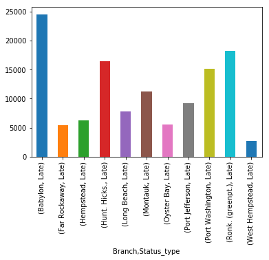

```python
s1.plot.bar()
```

The line delays most is Babylon and the frequency reaches to 24531. The line delays least is West Hempstead and the frequency reaches to 2717.

### Q3: What is the average delay time?

```python
avg_dl_t=df_delay['Late_Mins'].agg('mean')
print('The average delay time for all lines is:','%.2f'%avg_dl_t,"mins")
```

```
The average delay time for all lines is: 12.79 mins
```

#### The average delay time for each line

```python
s2=df_delay.groupby(['Branch'])['Late_Mins'].agg([('Avg Delay Time/Mins','mean')])
df2=s2.reset_index()
df2['Avg Delay Time/Mins']=df2['Avg Delay Time/Mins'].apply(lambda x: round(x,2))#Keep the calculation results in two decimal.
df2
```

|  | Branch | Avg Delay Time/Mins |
| --- | --- | --- |
| 0 | Babylon | 11.56 |
| 1 | Far Rockaway | 11.52 |
| 2 | Hempstead | 12.13 |
| 3 | Hunt. Hicks. | 12.46 |
| 4 | Long Beach | 11.43 |
| 5 | Montauk | 16.58 |
| 6 | Oyster Bay | 14.13 |
| 7 | Port Jefferson | 14.21 |
| 8 | Port Washington | 10.45 |
| 9 | Ronk. (greenpt.) | 14.68 |
| 10 | West Hempstead | 10.89 |

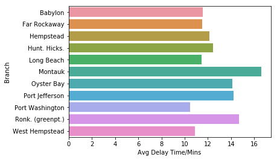

```python
sns.barplot(x='Avg Delay Time/Mins',y='Branch',data=df2)
```

```python
df['Period'].value_counts().to_frame()
```

|  | Period |
| --- | --- |
| Off Peak | 85038 |
| PM Peak | 27650 |
| AM Peak | 22421 |

```python
df3=df.groupby(['Status_type'])['Period'].value_counts().unstack()
df3
```

| Period Status_type | AM Peak | Off Peak | PM Peak |
| --- | --- | --- | --- |
| Canceled | 1521 | 3633 | 3035 |
| Late | 20044 | 78202 | 24172 |
| Partially Canceled | 856 | 3203 | 443 |

```python
labels = ['AM Peak', 'Off Peak', 'PM Peak']
explode = [0, 0.1, 0]
fracs1 = [1521/len(df[df['Status_type'] == 'Canceled']), 3633/len(df[df['Status_type'] == 'Canceled']), 3035/len(df[df['Status_type'] == 'Canceled'])]
fracs2 = [20044/len(df[df['Status_type'] == 'Late']), 78202/len(df[df['Status_type'] == 'Late']), 24172/len(df[df['Status_type'] == 'Late'])]
fracs3 = [856/len(df[df['Status_type'] == 'Partially Canceled']), 3203/len(df[df['Status_type'] == 'Partially Canceled']), 443/len(df[df['Status_type'] == 'Partially Canceled'])]
```

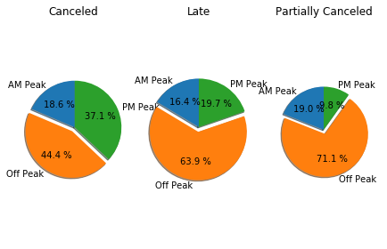

```python
fig1 = plt.subplot(131)
plt.pie(x=fracs1, labels=labels, explode=explode,autopct='%3.1f %%',
        shadow=True, labeldistance=1.1, startangle = 90,pctdistance = 0.6)
plt.axis('equal')
plt.title('Canceled')

fig2 = plt.subplot(132)
plt.pie(x=fracs2, labels=labels, explode=explode,autopct='%3.1f %%',
        shadow=True, labeldistance=1.1, startangle = 90,pctdistance = 0.6)
plt.axis('equal')
#plt.axes(aspect=1)
plt.title('Late')

fig3 = plt.subplot(133)
plt.axis('equal')  # set this , Figure is round, otherwise it is an ellipse
plt.pie(x=fracs3, labels=labels, explode=explode,autopct='%3.1f %%',
        shadow=True, labeldistance=1.1, startangle = 90,pctdistance = 0.6)

plt.title('Partially Canceled')

plt.tight_layout()
plt.show()
```

As can be seen in the above pie charts, the canceled, late and partially canceled cases often happen in off-peak periods. What's more serious is that over 50% of late and partially canceled cases happen in off-peak periods repectively.

### Q5: How many Canceled , Late , and Partially Canceled entries are in each year?

```python
df4=df.groupby(['Year', 'Status_type'])['Date'].count().unstack()
df4
```

| Status_type Year | Canceled | Late | Partially Canceled |
| --- | --- | --- | --- |
| 2011 | 1172 | 12733 | 575 |
| 2012 | 458 | 11141 | 366 |
| 2013 | 844 | 12994 | 502 |
| 2014 | 787 | 16633 | 470 |
| 2015 | 1206 | 17343 | 623 |
| 2016 | 1154 | 14783 | 477 |
| 2017 | 1279 | 17782 | 709 |
| 2018 | 1289 | 19009 | 780 |

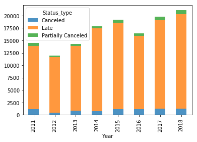

```python
df4.plot.bar(stacked=True,alpha=0.8,)
```

As can be seen in the above graph, there are the most off-the-schedule trains in 2018, with a number of 1289 in Canceled,19009 in Late and 780 in Partially Canceled respectively. And the frequency of off-the-schedule trains in 2012 is the lowest.The overall trend seems to be fluctuant.

### Q6: Is the delay associated with a certain station?

```python
df5=df[df['Status_type'] == 'Canceled'].groupby(['Depart','Arrive'])['Date'].count()
df5=pd.DataFrame(df5)
df5=df5.rename(columns={'Date':'Canceled'})
```

```python
df6=df[df['Status_type'] == 'Late'].groupby(['Depart','Arrive'])['Date'].count()
df6=pd.DataFrame(df6)
df6=df6.rename(columns={'Date':'Late'})
```

```python
df7=df[df['Status_type'] == 'Partially Canceled'].groupby(['Depart','Arrive'])['Date'].count()
df7=pd.DataFrame(df7)
df7=df7.rename(columns={'Date':'Partially Canceled'})
```

```python
result = pd.concat([df5,df6,df7],axis=1, sort=False)
result.head(30)
```

| Depart | Arrive | Canceled | Late | Partially Canceled |
| --- | --- | --- | --- | --- |
| Amagansett Station | Jamaica Station | NaN | 3.0 | NaN |
| Atlantic Terminal | Babylon Station | 65.0 | 948.0 | 17.0 |
|  | Far Rockaway Station | 82.0 | 1522.0 | 96.0 |
|  | Garden City Station | NaN | 1.0 | NaN |
|  | Hempstead Station | 61.0 | 2115.0 | 75.0 |
|  | Huntington Station | 31.0 | 246.0 | 2.0 |
|  | Jamaica Station | 19.0 | 56.0 | NaN |
|  | Long Beach Station | 56.0 | 864.0 | 35.0 |
|  | Lynbrook Station | NaN | NaN | 1.0 |
|  | Ronkonkoma Station | 40.0 | 294.0 | 13.0 |
|  | Valley Stream Station | NaN | 3.0 | NaN |
|  | West Hempstead Station | 38.0 | 1007.0 | 31.0 |
| Babylon Station | Atlantic Terminal | 17.0 | 299.0 | 18.0 |
|  | Freeport Station | NaN | 6.0 | NaN |
|  | Jamaica Station | NaN | 9.0 | 2.0 |
|  | Montauk Station | 1.0 | 159.0 | 18.0 |
|  | Patchogue Station | 103.0 | 1559.0 | 5.0 |
|  | Penn Station | 455.0 | 10304.0 | 420.0 |
|  | Speonk Station | 42.0 | 715.0 | 62.0 |
|  | West Side Yard | 4.0 | 5.0 | NaN |
| Bellmont Race Track | Jamaica Station | 1.0 | 12.0 | NaN |
|  | Penn Station | NaN | 3.0 | NaN |
| Bethpage Station | Penn Station | 22.0 | 379.0 | NaN |
| Brentwood Station | Penn Station | 1.0 | 49.0 | 2.0 |
| Bridgehampton Station | Jamaica Station | 1.0 | 17.0 | NaN |
| Central Islip Station | Penn Station | 24.0 | 133.0 | 4.0 |
| Cold Spring Harbor Sta. | Penn Station | 25.0 | 181.0 | 1.0 |
| Deer Park Station | Riverhead Station | 11.0 | 18.0 | 21.0 |
| East Williston Station | Penn Station | 9.0 | 125.0 | 5.0 |
| Far Rockaway Station | Atlantic Terminal | 83.0 | 1570.0 | 129.0 |

### Q7: Average late minutes by station and month in Year2018

```python
df2018=df[df['Year'] == 2018]
df2018.Depart.unique()
```

```
array(['Penn Station', 'Jamaica Station', 'Long Beach Station',
       'Babylon Station', 'Far Rockaway Station', 'Montauk Station',
       'Port Washington Station', 'Ronkonkoma Station',
       'Huntington Station', 'Hempstead Station', 'Patchogue Station',
       'Oyster Bay Station', 'Speonk Station', 'Port Jefferson Station',
       'Massapequa Park Station', 'Hicksville Station',
       'Atlantic Terminal', 'West Hempstead Station', 'Freeport Station',
       'Long Island City', 'Hunterspoint Ave.', 'Farmingdale Station',
       'Great Neck Station', 'Central Islip Station', 'Wantagh Station',
       'Westbury Station', 'Little Neck Station', 'Merrick Station',
       'Bethpage Station', 'Valley Stream Station',
       'East Williston Station', 'Cold Spring Harbor Sta.',
       'Greenport Station', 'Yaphank Station', 'Stony Brook Station',
       'Lindenhurst Station', 'Brentwood Station', 'Southampton Station',
       'Bellmont Race Track', 'Southampton College'], dtype=object)
```

#### For Depart Station

```
array([<matplotlib.axes._subplots.AxesSubplot object at 0x15ee1e2e8>,
      dtype=object)
```

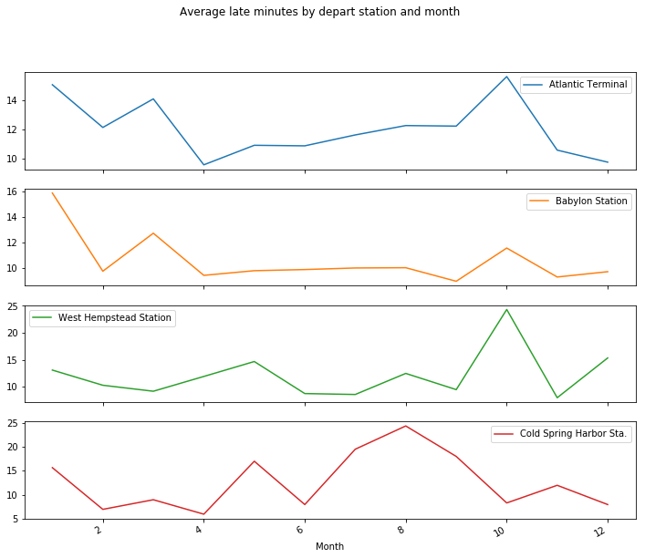

```python
d_avg_dl_time=df2018.pivot_table('Late_Mins',index='Month',columns='Depart',aggfunc='mean')
d_subset=d_avg_dl_time[['Atlantic Terminal','Babylon Station','West Hempstead Station','Cold Spring Harbor Sta.']]
d_subset.plot(subplots=True,figsize=(12,10),grid=False,title='Average late minutes by depart station and month')
```

#### For Arrive Station

```
array([<matplotlib.axes._subplots.AxesSubplot object at 0x160b90198>,
      dtype=object)
```

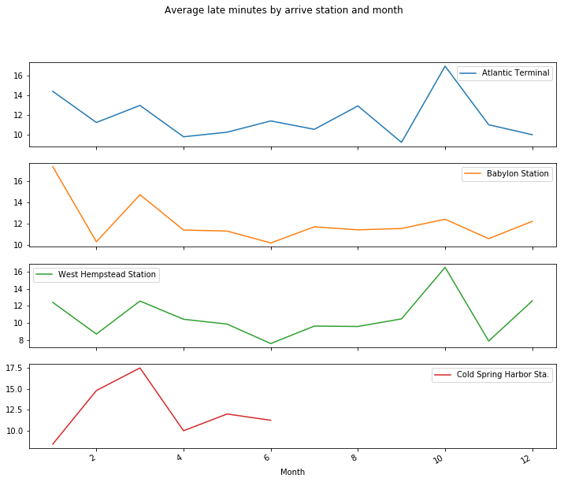

```python
a_avg_dl_time=df2018.pivot_table('Late_Mins',index='Month',columns='Arrive',aggfunc='mean')
a_subset=a_avg_dl_time[['Atlantic Terminal','Babylon Station','West Hempstead Station','Cold Spring Harbor Sta.']]
a_subset.plot(subplots=True,figsize=(12,10),grid=False,title='Average late minutes by arrive station and month')
```

## Future Work

1. In the process of data analysis, it is often necessary to visualize the data and explore the intrinsic link between the data.In general, we can draw images with Matplotlib in Python. However, the drawing process is static, that is, each time we need to recall the drawing statement for different data, the drawing is displayed. Our goal is to enable interactive mapping of differt data in conjunction with GUI components. In this way, the data can be dynamically adjusted and the image can be drawn in the displayed GUI interface.For example, as for the last picture above, we just randomly select 4 different stations to plot the line graphs,with GUI everytime the user put a station as input, it will display corresponding line graph.
1. Other factors might affect whether the train is late or canceled,such as weather. In this way we can crawl data about weather on the official website and relate it to the entries in the current dataset and test whether trains' status types are related to weather.
1. We can build models based on columns given in the dataset to predict which statues type of a train will be or whether this train will be late and if so,how many minutes it will be delayed.